# PP 639 R help

Nathan Mather

December 17, 2020

The purpose of this document is to provide students with a description of how to perform R-related tasks for the problem sets. This begins with sections on the basic set up of R and some foundational concepts for those new to the program.

# Basic Setup

## Installing R and Rstudio

R is the program that actually does the computing and statistical work. However, the basic user interface (GUI) that comes with R is not particularly user friendly. Rstudio is another program that makes using R easier by providing a more user-friendly interface and tools for things like formatting and saving code. Technically, R studio is what is called an “integrated development environment (IDE)” which is a common tool for programming languages. More simply though, it just makes writing, saving, and running code easier. It is a lot like how we could just type papers in a text editor on our computer, but word gives us a bunch of tools like spell check to help us out.

This page will walk you through the steps to install both R and Rstudio. https://rstudio-education.github.io/hopr/starting.html

Now that you have R and Rstudio installed, you can open up Rstudio, just like you would any other computer application, and you are ready to get started.

## R scripts

Writing code has several advantages over a point and click program, but the primary advantage is that code is reproducible. We can look at the code and verify exactly what happened, run it again, or edit small parts of it without redoing the entire process. In order to do this, we want to write and save our code in what is called an R script. This is very much like saving a word document or any other text file. To open a new R script in Rstudio click file -> New File -> R script.

Now rather than typing your code into the console, you can write it in this R script. You can save the script by selecting it and hitting file -> save.

To run code from the script you can do a few things. You can click the run button in the top right corner, and it will run the line that your cursor is on. You can also highlight a section and hit run and it will run the highlighted code. Alternatively, you can just hit ctrl+enter and it will do the same thing as the button.

“ctrl + alt + B” and “ctrl + alt + E” are also useful shortcuts. They will run all the code before and after the cursor respectively.

# Understanding R

Here we will cover some of the basics of how R works.

## Functions

Just about everything you do in R is accomplished using functions. A function takes a set of inputs called “Arguments” and uses that data to return some type of output. For example, if we want to load data into R we will use a function called *load*. *load* is a function for reading in data saved as an rdata file.

The First argument for the *load* function is the *file* argument. This is where we input the file path for the data that we want R to load. When we run the function, it uses that information to return the data in our specified file. You can see all the arguments for any function by using the *help* function and entering the name of the function as a character sting (a character string means put the name in quotes). For example

```r
help("load")
```

will bring up the help file for the load function.

we can fill in arguments explicitly when we run a function, like so

```r
load(file = "my_r_data.RData")
```

If you are entering arguments out of order, you will need to explicitly list the argument names, assign them values with an equal sign, and separate arguments with a comma. This is also a decent habit as it makes it explicit what is happening in your code. For the first argument, however, the argument name is often left out and abbreviated like so.

```r
load("my_r_data.RData")
```

R knows that since this character string comes first, it is the file argument.

Using help files and remembering the syntax for entering arguments to a function will allow you to learn and use new functions on your own.

## Operators

One nice shorthand for accessing help files is the `?` operator. rather than typing *help(“load”)* We can instead just type *?load* to see the help file for the load function.

Operators do not follow the syntax of a function and there are a handful of other very useful operators. For example, + - < > <= >=. A more extensive list can be found here: https://www.tutorialspoint.com/r/r_operators.htm

With these we can do things like add and subtract numbers or compare the size of numbers.

```r
# add and subtract
5+20-3
```

```
## [1] 22
```

```r
# compare two numbers
10 >= 4
```

```
## [1] TRUE
```

## Packages

You can do a lot with the basic tools in R. However, as an open-source program, there are a number of user written packages to do more complicated tasks or to make basic tasks easier. We will use several of these packages in this class. Packages are essentially a set of new functions for you to use. For example, the *haven* package has a function to read in Stata .dta files.

The first time you use a new package, you need to install it onto your computer. With the *install.packages* function.

```r
install.packages("haven")
```

This downloads all the files to your computer. Even after it is installed, every time we start a new session of R we will have to tell R we want to use the functions in that package with the *library* function.

```r
library(haven)
```

Now we can use functions in the package *haven*, like *read_dta*.

## Loading Data

We talked about loading data in the Function section, but there are a few more bits of information that will be useful. First, there is not a general function that will read any data type. There are different functions for different data types. *load* reads rdata, *read.csv* reads csv and comes pre installed on R. *fread* is another, faster, function to read in csv files from the *data.table* package. In this class, we will often be using the *read_dta* function from the *haven* package to read in Stata .dta files.

For any of these functions we need to tell R the entire pathway to the data set we want R to read. There are a few ways to do this. In windows, you can actually go to the file in the windows file explorer, copy the file, then hit paste in an R studio script. This will fill out the entire pathway.

Alternatively, you can start typing the file path in your script. For example, by documents are on my c drive so I would start with “C:/”. If you then hit the Tab key, Rstudio opens up a window to allow you to select the folder you want. If you keep typing it narrows the files and folders to those matching what you have typed.

An Important note here is that R requires forward slashes between folders. (not backslashes)

Often times, we want to load multiple files from the same folder. There are two main ways to do this. This first is by changing your working directory. This is a folder on your computer’s drive that will contain the work related to your project. For example, I could make a folder called Problem Set 1. Most likely, you will want to save any data sets that you will be using for your project into this folder as well. Now we can set our working directory with *setwd*

```r
setwd("C:/Users/Nmath_000/Documents/MY_FOLDER/")
```

Now that you have issued this command, R will read files from this directory and save files to this directory, unless you specify a different location in your command. So we can skip the full pathway and just type

```r
read_dta("my_data_data.dta")
```

This will tell R to look for data at this path: “C:/Users/Nmath_000/Documents/MY_FOLDER/my_data_data.dta”

Sometimes (probably not in this class) you will have multiple folders with relevant data in them. In this case, it might be easier to save those folder paths as objects (if you are not sure what that is check out the objects section). We can do that like so:

```r
folder_1 <- "C:/Users/Nmath_000/Documents/MY_FOLDER_1/"
folder_2<- "C:/Users/Nmath_000/Documents/MY_FOLDER_2/"
```

Now if we want to load data from one of those folders, we use the *paste0* command which connects two character strings

```r
my_data <- read_dta(paste0(folder_1, "my_stata_data.dta"))
```

This also tells R to read in data from “C:/Users/Nmath_000/Documents/MY_FOLDER_1/my_Stata_data.dta”

## Creating Objects and Assigning Values

In R, all types of data are treated as objects. To create new objects, you will need to assign values to new objects using “<-”, (= can also be used but is less common). For example:

```r
a <- 5
```

Creates an object called “a” which contains the number 5. We can use this object in functions or with operators.

```r
is.na(a)
```

```
## [1] FALSE
```

```r
a + 1
```

```
## [1] 6
```

We can use the *c* function to create vectors and assign them to an object.

```r
b <- c(1,2,3,4)
b
```

```
## [1] 1 2 3 4
```

When we load in Stata data, it will print it to the console unless we tell R to assign that data to a new object. For example, let’s load the data from our first problem set. You can enter the entire file path, or use one of the methods we discussed in the “loading data” section.

```r
# read in the library if you have not already
library(haven)

# read in data
ps1_df <- read_dta("Full file path to your folder/mich_charters_2014_ps1.dta")
```

Now we have our data saved as an object called *ps1_df*

## Accessors

Often we will want to access a specific subset of the data in an object. Take a look at our *ps1_df* data set either by clicking on it in the environment window or using the following command to bring up an interactive table:

```r
View(ps1_df)
```

*ps1_df* a table of data with many named columns. For much of what we are going to do we will want to access specific columns of this data set.

R has three different “accessors” to access the variables or vectors in your data set (and for generally subsetting all objects). The easiest one to use for simple, interactive coding (like most of what you will do in this class) is the dollar sign “$”. Using “$” we can access a single column in our data set using the name of that column. Using the dollar sign will return the column as a vector rather than a data.frame. Here we can see the class of this vector is a *numeric*.

```r
class(ps1_df$year)
```

```
## [1] "numeric"
```

In practice, this is equivalent to using double brackets and the vector name in quotes

```r
class(ps1_df[["year"]])
```

```
## [1] "numeric"
```

Using the dollar sign is simply shorter and easier to use since Rstudio will fill in suggestions as you type, and it requires fewer characters. However, the brackets are useful for more advanced coding techniques like loops.

The third accessor is a single bracket and is for subsetting. The key difference is that a single bracket generally returns the same type of object you are operating on. It subsets the object, maintaining the class. In this case ps1_df is a data.frame, so a single bracket will also return a data.frame.

```r
class(ps1_df["year"])
```

```
## [1] "tbl_df"     "tbl"        "data.frame"
```

```r
head(ps1_df[c("year", "enroll")])
```

| year | enroll |
| --- | --- |
| 2014 | 318 |
| 2014 | 391 |
| 2014 | 781 |
| 2014 | 513 |
| 2014 | 298 |
| 2014 | 371 |

We can also create objects using our accessors

```r
year_vector <- ps1_df$year
```

Now we have an object called *year_vector* that is a single vector of the year column from the *ps1_df* data.frame.

We can also use accessors to input specific data to functions and output can also be assigned to an object. Take the *mean* function, for example, which calculates the mean.

```r
mean(ps1_df$year)
```

```
## [1] 2014
```

The code above simply prints the mean to our console for us to see. But, if we want to use that mean in some way, we can assign it to an object.

```r
my_mean <- mean(ps1_df$year)
```

Now we have an object called *my_mean* that contains the mean of the year column. We can use for other analysis.

If you are looking for more details this blog post digs deeper into the differences between the accessors: https://www.r-bloggers.com/r-accessors-explained/

## Comments

An important part of writing code is commenting that code. Comments are just notes you write within the code to make it easier to follow and understand. This is especially helpful when working on a project with others but is still important when working on your own. Even if you understand everything perfectly now, coming back to code later with no comments can be confusing. To add a comment use the hash or pound sign “#”

```r
# I can write anything after this and it will just show up as text
```

# Example Data Sets

For the rest of the examples I will use a few data sets from this class. I have already loaded in the problem set 1 data above. I will provide some brief explanation of data and variables in the examples, but you can see the problem sets if you would like more detailed information.

```r
# set base path for data
base_path <- "Path to the folder with your data/"

ps2_df <- read_dta("Full file path to your data")

# read in data
ps2_df <- read_dta(paste0(base_path, "pset2.dta"))
ps3_df <- read_dta(paste0(base_path, "Earnings_and_Height.dta"))
ps4_df <- read_dta(paste0(base_path, "civilwar_v2.dta"))
ps5_df <- read_dta(paste0(base_path, "job_training_f19.dta"))
```

# Data Manipulation

There are two main packages/approaches for data management and cleaning. They are dplyr and data.table. These packages cover tasks like creating new columns, editing old columns, creating tables, and more. Both packages have pros and cons but which you should use is a matter of opinion. You can also do everything in base R. This will likely get you by just fine in this class, but as you advance in R coding knowing at least one of these data manipulation packages will be incredibly useful.

The first is dplyr which is part of a larger collection of packages called tidyverse. It is built so that code reads more like a sentence. Learning this package requires learning a number of new functions and how they interact. It is generally slower than data.table and I find it harder to use when writing your own functions. That being said, many people find it easier to read and understand.

Data.table is generally faster and so would be better for big data. It has some of its own functions but is largely based around introducing a new enhanced version of data.frames, which are the standard data structure for storing data in base R. It introduces a new syntax to do much more within the single bracket accessor […]. Learning data.table mostly involves getting used to this syntax and understanding how to use it with other functions. This generally makes the code more compact than dplyr. I also personally find it easier to use when writing your own functions.

This page gives a comparison of many common tasks: https://atrebas.github.io/post/2019-03-03-datatable-dplyr/

While I mostly use data.table for my own work, I use tidyverse for most of the examples here as I think it is more common.

## tidyverse/dplyr

I will just give you a brief overview and some useful examples here. If you are looking for a complete introduction to the package, I suggest going through the vignette for the package. That is located here:

https://cran.r-project.org/web/packages/dplyr/vignettes/dplyr.html

dplyr assists with data manipulation by supplying a number of “verbs”, functions that correspond to the most common data manipulation tasks. A more complete list can be found in the vignettes I linked above. First remember to install the package if you haven’t already and then library it.

```r
install.packages("tidyverse")
library(tidyverse)
```

### Mutate

One of the most common verbs we can use is the *mutate* function. *mutate* is used to create new columns in our data set. Let’s take out problem set 3 data, which looks at earnings, and use *mutate* to create an experience variable called *exp* that is equal to the *age* variable minus *educ* minus 6. This creates an entirely new data.frame that now contains this new column. To avoid getting a bunch of data sets, we assign this output to *ps3_df* and overwrite our old version of the data. Notice that we can use multiple columns of *ps3_df* and combine them with different functions or, in ths case, operators.

```r
# add experience variable
ps3_df <- mutate(ps3_df, exp = age - educ - 6)
```

### Filter

Filter is another useful verb. It is a function to subset data in a more convenient way than using accessors. we can us the `filter` command to subset to rows where *age* is less than 50. The first argument is the data set. The following arguments are logical conditions for subsetting rows.

```r
ps3_sub <- filter(ps3_df, age < 50)
```

### summarize

summarize or summarise (both work) is an extremely useful verb for summarizing data. This verb is for creating tables of summary statistics. The first argument is the data set (this is true of all dplyr verbs). Next, we enter name value pairs in the form “name = value”. an example is below where we get the mean earnings, the standard deviation, and the number of observations in our data set of people under 50.

```r
  # summarize the data
  sum_tab <- summarise(ps3_sub,
                       mean = mean(earnings),
                       StdDev = sd(earnings),
                       Freq = n())
  sum_tab
```

| mean | StdDev | Freq |
| --- | --- | --- |
| 46642.54 | 26731.01 | 13988 |

### group_by

Group by is only really useful in combination with other verbs. It groups the data set so other verbs know to operate on each group separately. For example, say we want to make the same summary table above, but get the results separately for married and single observations.

```r
  # group the data
  ps3_sub <- group_by(ps3_sub, married)

  sum_tab2 <- summarise(ps3_sub,
                       mean = mean(earnings),
                       StdDev = sd(earnings),
                       Freq = n())
  sum_tab2
```

| married | mean | StdDev | Freq |
| --- | --- | --- | --- |
| 0 | 33240.04 | 21822.51 | 4908 |
| 1 | 53886.98 | 26340.89 | 9080 |

It is important to remember that once data is grouped, it stays grouped until you ungroup it. This can lead to errors if data is grouped when you are not expecting it, so be careful and always be sure to ungroup data when you are finished.

```r
  # group the data
  ps3_sub <- ungroup(ps3_sub)
```

### The pipe operator

All of the tidyverse code we have run so far can actually be made much more compact with a dplyr operator called “the pipe” (technically it is originally from the *magrittr* package, but dplyr is designed to work well with it). The pipe is the `%>%` operator. This allows the code to be read more like a sentence, cuts down on typing, and bypasses the need to create intermediate objects.

This is what the vignette says on it:

All of the dplyr functions take a data frame (or tibble) as the first argument. Rather than forcing the user to either save intermediate objects or nest functions, dplyr provides the %>% operator from magrittr. x %>% f(y) turns into f(x, y) so the result from one step is then “piped” into the next step. You can use the pipe to rewrite multiple operations that you can read left-to-right, top-to-bottom (reading the pipe operator as “then”).

We can create our final summary table instead with piped commands.

```r
# first line sets the input data
sum_tab_pipe <- ps3_df %>%
  # now add our exp variable
  mutate(exp = age - educ - 6) %>%
  # filter to less than 50
  filter( age < 50) %>%
  # group by "married"
   group_by( married) %>%
  #make summary table
   summarise(mean = mean(earnings),
             StdDev = sd(earnings),
             Freq = n()) %>%
  # ungroup
  ungroup()

  sum_tab_pipe
```

| married | mean | StdDev | Freq |
| --- | --- | --- | --- |
| 0 | 33240.04 | 21822.51 | 4908 |
| 1 | 53886.98 | 26340.89 | 9080 |

### Operating on Multiple Columns (dplyr)

Sometimes you will want to run something on a bunch of columns at once. For example, let’s say we want the mean of a bunch of columns at once. We could type it all out, but a few tools can make it much easier.

The newest function to do this is *across*. It can be used with a variety of other functions to apply the same transformation to multiple columns. For example, it can be used inside summarize to get the mean of “exp”, “earnings”, “age”, and “educ”

```r
across_tab <- ps3_df %>%
  summarise(across(c("exp", "earnings", "age","educ"), mean, na.rm = TRUE),
            n_obs = n())
across_tab
```

| exp | earnings | age | educ | n_obs |
| --- | --- | --- | --- | --- |
| 21.3822 | 46875.32 | 40.91953 | 13.53733 | 17870 |

Across is fairly new. Prior to that people used “scoped variants” like *summarise_at*, *summarise_if*, and *summarise_all*, which exist for various functions. I will show one example. While it’s probably better to get used to using across, I include this for reference as you may come across these in old code.

```r
  # get means by group
  sum_at_tab <- ps3_df %>%
    summarise_at(c("exp", "earnings", "age","educ"), mean, na.rm = TRUE)

sum_at_tab
```

| exp | earnings | age | educ |
| --- | --- | --- | --- |
| 21.3822 | 46875.32 | 40.91953 | 13.53733 |

## data.table

I will just give you a brief overview and examples here. If you are looking for a complete introduction to the package, I suggest going through the vignette for the package. That is located here:

https://cran.r-project.org/web/packages/data.table/vignettes/datatable-intro.html

This package is built around an enhanced version of data.frames called data.tables. We can create a version of our *ps3_df* data set that is a data.table instead of a data.frame. make sure to install the package if you haven’t yet and also library in the package.

```r
install.packages("data.table")
library(data.table)
```

```r
# note the data.table version is dt not df
ps3_dt <- data.table(ps3_df)
```

data.table enhances the single bracket accessor with the following syntax

```r
ps3_dt[i ,j , by]
```

The i section is for subsetting or reordering rows. The j section is for selecting columns or operating on columns. The by section allows us to group by variables. In other words, Take the data.table, subset/reorder rows using i, then calculate j, grouped by `by`. Lets start by taking a look at the i section.

The most important update is that we can now subset using logical conditions. For example, we may want to only consider people under 50:

```r
ps3_dt_sub <- ps3_dt[age < 50]
```

We can also select columns in the j section. Check out the vignette for all the different ways you can do this, but one of the most useful ways is within a list. This allows is to rename columns as we select them.

```r
 ps3_dt[, list(new_col1 = age, new_col2 = earnings)]
```

| new_col1 | new_col2 |
| --- | --- |
| 48 | 84054.750 |
| 41 | 14021.395 |
| 26 | 84054.750 |
| 37 | 84054.750 |
| 35 | 28560.387 |
| 25 | 23362.873 |
| 29 | 38925.336 |
| 44 | 84054.750 |
| 50 | 84054.750 |
| 38 | 84054.750 |

[output cut: 9990 more lines]

This might not seem that useful, but it is when combined with another important feature. We can also operate on columns within the j section. For example, we could get the mean and standard deviation of earnings, and the number of observations, name them, and return them as a new data.table. This is great for producing summary statistics.

```r
 sum_dt <- ps3_dt[, list(mean = mean(earnings),
                         Std.Dev = sd(earnings),
                         Freq = .N)]
sum_dt
```

| mean | Std.Dev | Freq |
| --- | --- | --- |
| 46875.32 | 26923.29 | 17870 |

*.N* is a special symbol from data.table to use in the i and j positions that gives the number of observations. You can read more about it in the vignette I reference above.

We could combine this with the by argument to get these statistics by group. For example let’s look at earnings for married and unmarried people.

```r
 sum_dt2 <- ps3_dt[, list(mean = mean(earnings),
                         Std.Dev = sd(earnings),
                         Freq = .N),
                  by = married]
sum_dt2
```

| married | mean | Std.Dev | Freq |
| --- | --- | --- | --- |
| 1 | 54139.52 | 26443.65 | 11641 |
| 0 | 33299.70 | 22132.80 | 6229 |

Another important feature of the J argument is that it allows us to create new columns within an existing data.table. This changes the existing data.table and so we do not need a `<-` to assign it. (Technically this is assigning the new column by reference and avoids copying a lot of data. This is part of why data.table is so fast). We do this with the assignment operator “:=”. For example let’s create a new column called `exp` that is equal to age - education - 6.

```r
 ps3_dt[,  exp := age - educ - 6 ]
```

This can be combined with the i and by commands to make more complicated columns. For example, we can create a binary age variable based on if the person is over 50.

```r
 ps3_dt[age > 50, over_50 := TRUE ]
 ps3_dt[age <= 50, over_50 := FALSE ]
```

Or we can assign the mean earnings by age to a new column

```r
 ps3_dt[,m_earn_age := mean(earnings), by = age ]
```

These new variables are in our ps3_dt data.table without needing to assign output or over write the object.

Putting all of this together we can create a complicated summary table that subsets our data to people under 50 and summarizes earnings for married and unmarried people.

```r
sum_tab3 <- ps3_dt[age < 50,
                       list(mean = mean(earnings),
                              Std.Dev = sd(earnings),
                              Freq = .N),
                       by = married]

# sort the rows so it looks nice
sum_tab3 <- setorder(sum_tab3)
sum_tab3
```

| married | mean | Std.Dev | Freq |
| --- | --- | --- | --- |
| 0 | 33240.04 | 21822.51 | 4908 |
| 1 | 53886.98 | 26340.89 | 9080 |

### Operating on Multiple Columns (data.table)

Sometimes you will want to operate on multiple columns at once without doing a bunch of typing. For example, let’s say we want to take the mean of multiple columns. For this we will use the function *lapply*. *lapply* is an extremely useful base R function. It takes a vector or list and runs a function on every element of that list and returns the results in a list. This is used in combination with two more features of data.table. *.SD* and *.SDcols*. *.SD* is basically a shorthand way to reference the data table you are working on and *.SDcols* specifies specific columns to be used with *.SD*. Putting this all together, we can get the mean of “exp”, “earnings”, “age”, and “educ” in one line.

```r
ps3_dt[ , lapply(.SD, mean), .SDcols = c("exp", "earnings", "age","educ")]
```

| exp | earnings | age | educ |
| --- | --- | --- | --- |
| 21.3822 | 46875.32 | 40.91953 | 13.53733 |

This can be used with subsets and by groups as well

```r
ps3_dt[age < 50 ,
       lapply(.SD, mean),
       by = married,
       .SDcols = c("exp", "earnings", "age","educ")]
```

| married | exp | earnings | age | educ |
| --- | --- | --- | --- | --- |
| 1 | 17.63965 | 53886.98 | 37.21740 | 13.57775 |
| 0 | 16.35350 | 33240.04 | 36.11532 | 13.76182 |

# Haven Labels

Stata has a feature to add labels to data. So, you will have actual values for the data (say 1-3) and then labels for those numbers. Like Wisconsin, Ohio, and Michigan. When you read in a dta file with haven it keeps those labels for you.

There are a lot of features to this that I have not dug into much, but there are two important things to note. First, you can look at the labels using *print_labels*

```r
print_labels(ps3_df[["region"]])
```

```
##
## Labels:
##  value       label
##      1 1:Northeast
##      2   2:Midwest
##      3     3:South
##      4      4:West
```

Second, converting the table to a data.table or tibble will get rid of the labels. So will a lot of general functions.

# Confidence Intervals

In base R, the functions to perform T-tests also report confidence intervals. Building confidence intervals in R “by hand” is also possible using standard mathematical operators.

The *t.test()* function will report a confidence interval for a sample mean. The first argument of the function is a numeric vector (i.e. the variable of interest). A relevant second argument for confidence intervals is *conf.level*, in which the user can set the level of confidence as a proportion. The default is .95.

Let’s make a 95% confidence interval for the mean of the variable *per_fl* from the problem set one data we loaded above called *ps1_df*.

```r
t.test(ps1_df$per_fl )
```

```
##
##  One Sample t-test
##
## data:  ps1_df$per_fl
## t = 82.894, df = 2053, p-value < 2.2e-16
## alternative hypothesis: true mean is not equal to 0
## 95 percent confidence interval:
##  0.4505149 0.4723481
## sample estimates:
## mean of x
## 0.4614315
```

We can see that the 95% confidence interval ranges from about 0.451 to 0.472. If we instead wanted a 99% confidence interval, we can do the following:

```r
t.test(ps1_df$per_fl, conf.level = .99)
```

```
##
##  One Sample t-test
##
## data:  ps1_df$per_fl
## t = 82.894, df = 2053, p-value < 2.2e-16
## alternative hypothesis: true mean is not equal to 0
## 99 percent confidence interval:
##  0.4470798 0.4757832
## sample estimates:
## mean of x
## 0.4614315
```

The interval is now wider, as it should be.

Looking at the output, you will see that R is performing a test of statistical significance versus the null hypothesis that the true mean is 0. Those are based on default values of the *t.test()* function. The output is not relevant for the confidence interval, but will be relevant in the section on T-tests.

It is also possible to build a confidence interval oneself by just using the formulas. Let’s make a 95% confidence interval for the mean of *per_fl* “by hand.”

```r
ybar <- mean(ps1_df$per_fl, na.rm = TRUE)
sdev <- sd(ps1_df$per_fl, na.rm = TRUE)
n    <- length(ps1_df$per_fl)

marg.error <- 1.96 * sdev/sqrt(n)
lower <- ybar - marg.error
upper <- ybar + marg.error
print(paste0("The 95% confidence interval for ", round(ybar,2)," is [",
             round(lower,2), ", ", round(upper,2),"]"))
```

```
## [1] "The 95% confidence interval for 0.46 is [0.45, 0.47]"
```

There is quite a bit going on in that last command. The main function is to print the output. The text to be printed is a bunch of stuff pasted together (the *0* at the end of *paste0* is optional; it tells R to not add spaces between the elements being pasted). The stuff being pasted together is a mixture of text (in quotes) and scalar values, separated by commas. The scalars are being rounded to 2 decimal places with the *round()* function.

#T-test

## One-Sample Significance Tests

With significance tests involving one sample, such as a sample mean or a sample proportion, we can use the same commands as those used to make confidence intervals. We now, however, will typically specify values for the null hypothesis.

Suppose that the null hypothesis is that the mean percent of free and reduced lunch, *per_fl*, is 0.45. Let’s perform a test of statistical significant with the default confidence level of .95. The function is *t.test()*. The null hypothesis is set by our specification of a value for *mu*. See the code below.

```r
t.test(ps1_df$per_fl, mu = .45)
```

```
##
##  One Sample t-test
##
## data:  ps1_df$per_fl
## t = 2.0536, df = 2053, p-value = 0.04014
## alternative hypothesis: true mean is not equal to 0.45
## 95 percent confidence interval:
##  0.4505149 0.4723481
## sample estimates:
## mean of x
## 0.4614315
```

We see the results show a $t$-statistic of 2.0536 and a $p$-value of 0.04014. The 95% confidence interval is produced by default. We can easily change that to another size just as above.

```r
t.test(ps1_df$per_fl, mu = .45, conf.level = .99)
```

```
##
##  One Sample t-test
##
## data:  ps1_df$per_fl
## t = 2.0536, df = 2053, p-value = 0.04014
## alternative hypothesis: true mean is not equal to 0.45
## 99 percent confidence interval:
##  0.4470798 0.4757832
## sample estimates:
## mean of x
## 0.4614315
```

## Two-Sample Significance Tests

Only slight modifications are necessary to use the *t.test()* function to perform two-sample tests of statistical significance. Typically, the crucial step is that we need a variable that has two categories to define the two samples.

Confidence intervals are also produced as part of the output for these two-sample significance tests.

Lets again test the mean of the precent free or reduced-price lunch variable *per_fl*. However, lets now test if the mean share of students eligible for free or reduced-price lunch is the same in charter and traditional public schools. For this we will also use the *charter* variable. This is a dichotomous variable in which a 1 signifies that a school is a charter school and a 0 signifies it is not. If there are any NA’s in this variable, the *t.test()* function will ignore them by default.

Inside the *t-test()* function, specify *per_fl ~ charter* as the first argument. This is a formula syntax that you will see repeated in many modeling functions. The syntax tells R to group the observations in *per_fl* by the categories of *charter*. The default null hypothesis is that there is a 0 difference of means. A different null hypothesis can be established with an argument that sets *mu* equal to some other value.

```r
t.test(per_fl ~ charter, data = ps1_df )
```

```
##
##  Welch Two Sample t-test
##
## data:  per_fl by charter
## t = -11.072, df = 201.17, p-value < 2.2e-16
## alternative hypothesis: true difference in means between group 0 and group 1 is not equal to 0
## 95 percent confidence interval:
##  -0.2831379 -0.1975342
## sample estimates:
## mean in group 0 mean in group 1
##       0.4407209       0.6810570
```

We see that the $t$-statistic is -11.072 and the $p$-value is 0 out to 15 decimal places. The means of the two groups are reported: 0.4407209 for non-charters and 0.6810570 for charter schools. R does not report it, but the difference of means is found by subtracting the mean for the second group from the mean for the first group. Finally, we also get the 95% confidence interval for the difference of means.

# Regressions

To run a linear regression in R, we can use the *lm()* function, which is for linear model. The first argument is the *formula* argument which has the following syntax: *formula = y ~ x1 + x2*, where *y* is the name of the dependent variable and *x1* and *x2* are the names of the independent variables. We can specify the data source in a separate argument (you can also put vector object names in the formula directly, but I won’t do that here or in the solutions).

Let’s use the ps2_df and regress *drate_esoph* on the *water_grade* and *airpollution*variables.

```r
ols_res <-  lm(drate_esoph ~ water_grade + airpollution, data = ps2_df)
ols_res
```

```
##
## Call:
## lm(formula = drate_esoph ~ water_grade + airpollution, data = ps2_df)
##
## Coefficients:
##  (Intercept)   water_grade  airpollution
##        3.279         1.816         6.764
```

This is very sparse output. We do not even get standard errors for the coefficients. Since we saved the model results to the data object *ols_res*, however, we can then ask for a *summary()* of the model.

```r
summary(ols_res)
```

```
##
## Call:
## lm(formula = drate_esoph ~ water_grade + airpollution, data = ps2_df)
##
## Residuals:
##     Min      1Q  Median      3Q     Max
## -15.944  -8.807  -5.190   2.329  75.509
##
## Coefficients:
##              Estimate Std. Error t value Pr(>|t|)
## (Intercept)    3.2791     4.6792   0.701   0.4846
## water_grade    1.8159     0.9392   1.933   0.0552 .
## airpollution   6.7641     6.9527   0.973   0.3323
## ---
## Signif. codes:  0 '***' 0.001 '**' 0.01 '*' 0.05 '.' 0.1 ' ' 1
##
## Residual standard error: 15.46 on 142 degrees of freedom
## Multiple R-squared:  0.03514,    Adjusted R-squared:  0.02155
## F-statistic: 2.585 on 2 and 142 DF,  p-value: 0.07891
```

R now reports a range of summary data, including standard errors, t-statistics, p-values, $R^2$, etc.

Adding additional independent variables is done by using the *+* operator in the formula. For example:

```r
  ols_res2 <-  lm(drate_esoph ~ water_grade + airpollution + urban + farmer, data = ps2_df)
```

## Categorical Variables

One thing to be mindful of when running regressions is categorical variables. For example, let’s take a look at the problem set 3 data. Suppose we want to do a regression of earnings on race.

```r
# run regression
cat_ols1 <- lm(earnings ~ race, data = ps3_df)
cat_ols1
```

```
##
## Call:
## lm(formula = earnings ~ race, data = ps3_df)
##
## Coefficients:
## (Intercept)         race
##       52909        -4353
```

This is close to what we want, but R is treating the race variable as numeric. We need to tell it that it is a categorical variable. We can see that the actual values for the race variable are numbered, even though there are haven labels for those numbers.

```r
table(ps3_df$race)
```

```
##
##     1     2     3     4
## 13767  2029  1349   725
```

```r
print_labels(ps3_df$race)
```

```
##
## Labels:
##  value              label
##      1 non-hispanic white
##      2 non-hispanic black
##      3           hispanic
##      4              other
```

What we need to do is convert this to a factor variable. While we are at it, let’s convert the *cworker* and *married* variables as well using tidyverse tools. (note that this gets rid of our haven labels)

```r
ps3_df <- ps3_df %>%
  mutate(across(c(race, cworker,married), as.factor))
```

Now when we run the regression, R treats race as a factor and we get a coefficient for each value

```r
# run regression
cat_ols1 <- lm(earnings ~ race, data = ps3_df)
cat_ols1
```

```
##
## Call:
## lm(formula = earnings ~ race, data = ps3_df)
##
## Coefficients:
## (Intercept)        race2        race3        race4
##       49422       -13260       -11893        -3542
```

## Variable Changes

Sometimes you may want to include functions of a particular variable in your regression formula. For example, let’s run a regression of earnings on age and age squared. We could create a new column in our data for age squared and use that, or we can specify age squared in our regression formula using the *I()* function.

```r
lm(earnings ~  age + I(age^2), data = ps3_df)
```

```
##
## Call:
## lm(formula = earnings ~ age + I(age^2), data = ps3_df)
##
## Coefficients:
## (Intercept)          age     I(age^2)
##    -34080.1       3735.2        -40.5
```

## Robust SE

To get heteroskedasticity robust standard errors, we will need some more packages. The *lmtest* and *sandwich* packages together give us the tools we need.

```r
library(lmtest)   # need this for robust SE
library(sandwich) # need this for robust SE
```

Rather than run the model with robust SEs, we are adjusting the results of our initial run.

From the sandwich package, we will use the function *vcovHC* that gives us Heteroskedasticity-consistent estimation of the covariance matrix of the coefficient estimates from our regression model. Then, we will use that covariance matrix in the *coeftest* function from the lmtest package. This is a generic function for estimating coefficients from covariance matrices and model objects. We will give it the robust matrix from *vcovHC* and so we will get robust coefficients. vcovHC by default computes “HC2” standard errors while Stata computes “HC1”. The distinction is not important, but to match Stata, I specify the argument *type=“HC1”*.

```r
  # robust results
  ols_res_r <- coeftest(ols_res, vcov = vcovHC(ols_res, type="HC1"))
  ols_res_r
```

```
##
## t test of coefficients:
##
##              Estimate Std. Error t value Pr(>|t|)
## (Intercept)    3.2791     3.7632  0.8714  0.38502
## water_grade    1.8159     1.0349  1.7547  0.08147 .
## airpollution   6.7641     5.6499  1.1972  0.23322
## ---
## Signif. codes:  0 '***' 0.001 '**' 0.01 '*' 0.05 '.' 0.1 ' ' 1
```

The *coeftest* also allows functions in the vcov argument. We could get the same result with the following.

```r
  # robust results
  ols_res_r2 <- coeftest(ols_res, vcov = vcovHC , type="HC1")
  ols_res_r2
```

```
##
## t test of coefficients:
##
##              Estimate Std. Error t value Pr(>|t|)
## (Intercept)    3.2791     3.7632  0.8714  0.38502
## water_grade    1.8159     1.0349  1.7547  0.08147 .
## airpollution   6.7641     5.6499  1.1972  0.23322
## ---
## Signif. codes:  0 '***' 0.001 '**' 0.01 '*' 0.05 '.' 0.1 ' ' 1
```

Here we are telling *coeftest* to use *vcovHC* to get the variance covariance matrix and we are passing the *type* argument on to *vcovHC* Although this requires slightly less typing, I typically do it the first way as I think it is more clear what is happening.

## Confidence Intervals

This can be done with the *confint* function. For example

```r
  # get confidence intervals
  ols_ci <- confint(ols_res)
  ols_ci
```

```
##                   2.5 %   97.5 %
## (Intercept)  -5.9708636 12.52910
## water_grade  -0.0406892  3.67241
## airpollution -6.9799702 20.50824
```

```r
  # get robust CI
  ols_ci_r <- confint(ols_res_r)
  ols_ci_r
```

```
##                   2.5 %    97.5 %
## (Intercept)  -4.1599296 10.718166
## water_grade  -0.2298866  3.861607
## airpollution -4.4045997 17.932868
```

## Tidying Results

The two main packages I use to clean up regressions results are *broom* and *stargazer*. Don’t forget to library the packages if you haven’t

```r
library(broom)
library(stargazer)
```

### broom and tidy

The *tidy* function from *Broom* takes the complicated model object returned by lm and creates a tibble (fancy data.frame) with the information we most often need. This is especially nice if you want to analyze the results using *tidyverse* functions or *data.table*.

```r
tidy_ols_r <- tidy(ols_res_r)
tidy_ols_r
```

| term | estimate | std.error | statistic | p.value |
| --- | --- | --- | --- | --- |
| (Intercept) | 3.279118 | 3.763156 | 0.8713745 | 0.38502053 |
| water_grade | 1.815860 | 1.034872 | 1.7546709 | 0.08147252 |
| airpollution | 6.764134 | 5.649874 | 1.1972185 | 0.23321620 |

For example, if we want to combine these results with the confidence intervals we created, it will be easier with the tidy data.

```r
  # cbind on the confidence interval
  cbind(tidy_ols_r, ols_ci_r)
```

|  | term | estimate | std.error | statistic | p.value | 2.5 % | 97.5 % |
| --- | --- | --- | --- | --- | --- | --- | --- |
| (Intercept) | (Intercept) | 3.279118 | 3.763156 | 0.8713745 | 0.38502053 | -4.1599296 | 10.718166 |
| water_grade | water_grade | 1.815860 | 1.034872 | 1.7546709 | 0.08147252 | -0.2298866 | 3.861607 |
| airpollution | airpollution | 6.764134 | 5.649874 | 1.1972185 | 0.23321620 | -4.4045997 | 17.932868 |

An important coding note is that cbind doesn’t ensure that the rows match up in a meaningful way. It just matches the first row with the first, second to second, and so on. This should be fine here since they should always come out in the same order but is not the best coding practice in general. If for whatever reason the data is not in the order you think it is, you will end up combining rows that don’t match. So, you have to be careful when you use cbind.

It is typically better practice to use a *merge* or *join* and specify specific columns that should match up when the rows are combined. I demonstrate this below

```r
  # convert matrix to a tibble, preserve rownames in column "term"
  ols_ci_r_tib <- as_tibble(ols_ci_r, rownames = "term")

  # Now merge by term to ensure rows match
  full_join(tidy_ols_r, ols_ci_r_tib, by = "term")
```

| term | estimate | std.error | statistic | p.value | 2.5 % | 97.5 % |
| --- | --- | --- | --- | --- | --- | --- |
| (Intercept) | 3.279118 | 3.763156 | 0.8713745 | 0.38502053 | -4.1599296 | 10.718166 |
| water_grade | 1.815860 | 1.034872 | 1.7546709 | 0.08147252 | -0.2298866 | 3.861607 |
| airpollution | 6.764134 | 5.649874 | 1.1972185 | 0.23321620 | -4.4045997 | 17.932868 |

### stargazer

*stargazer* is useful for presenting results from multiple models. It is meant to look like common Stata output. It has a lot of built in options, but we can mostly rely on the defaults. Each model enters as an un-named argument. Then we can set the *type* argument to “text” if we want to see the output printed as text. The *out* argument lets you save the table. Changing the file extension on your output allows you to save it as a .tex, .txt, .htm or .html file.

```r
  # use stargazer, save as a txt file
  stargazer(ols_res, ols_res_r , ols_res_r2,
            type = "text",
            out = "Path to save table.txt")
```

```
##
## ========================================================
##                             Dependent variable:
##                     ------------------------------------
##                         drate_esoph
##                             OLS            coefficient
##                                               test
##                             (1)            (2)     (3)
## --------------------------------------------------------
## water_grade                1.816*        1.816*  1.816*
##                           (0.939)        (1.035) (1.035)
##
## airpollution               6.764          6.764   6.764
##                           (6.953)        (5.650) (5.650)
##
## Constant                   3.279          3.279   3.279
##                           (4.679)        (3.763) (3.763)
##
## --------------------------------------------------------
## Observations                145
## R2                         0.035
## Adjusted R2                0.022
## Residual Std. Error  15.465 (df = 142)
## F Statistic         2.585* (df = 2; 142)
## ========================================================
## Note:                        *p<0.1; **p<0.05; ***p<0.01
```

# Linear Hypothesis Test

A linear hypothesis test can be done after a regression to, for example, check for the joint significance of several variables, or to check if two coefficients are equal. For this we will use the *linearHypothesis* function from the *car* package.

```r
library(car)
```

This function takes the model object created by, for example, lm as the first argument. The second argument is a vector of conditions entered as characters. Lets take the results *ols_res2* from the model we ran above. We can check for joint significance of all the variables like so.

```r
# test for joint significance
linearHypothesis(ols_res2, c( "water_grade = 0", "airpollution = 0", "urban = 0", "farmer = 0"))
```

|  | Res.Df | RSS | Df | Sum of Sq | F | Pr(>F) |
| --- | --- | --- | --- | --- | --- | --- |
| 1 | 144 | 35197.53 | NA | NA | NA | NA |
| 2 | 140 | 31688.03 | 4 | 3509.493 | 3.876298 | 0.005114474 |

Or, we could take the results of our categorical regression above and check the equivalence of two of the race categories.

```r
# test if these are equivalent
linearHypothesis(cat_ols1, c( "race2 = race3"))
```

|  | Res.Df | RSS | Df | Sum of Sq | F | Pr(>F) |
| --- | --- | --- | --- | --- | --- | --- |
| 1 | 17867 | 1.251335e+13 | NA | NA | NA | NA |
| 2 | 17866 | 1.251184e+13 | 1 | 1514134077 | 2.162074 | 0.1414712 |

# Generalized Linear Models

## Probit

To run a probit model we use the *glm* function. A probit model is a generalized linear model(a transformation of a linear model that is still linear in its parameters), so this makes sense. We enter our formula like most model functions in R as well as our data source. We also need to tell the *glm* function that we specifically want a probit model with the *family* argument. Here it is a binomial function with the probit link function. Importantly, *war* is an indicator for if a country is at war and so takes only two values. 0 or 1.

```r
# run model
probit_res <- glm(war ~ log_lagged_pop + log_lagged_gdp_per_capita +
                    ncontig + ethfrac + new_state + dem_high + instab + prior,
                  family = binomial(link = "probit"),
                  data = ps4_df)
probit_res
```

```
##
## Call:  glm(formula = war ~ log_lagged_pop + log_lagged_gdp_per_capita +
##     ncontig + ethfrac + new_state + dem_high + instab + prior,
##     family = binomial(link = "probit"), data = ps4_df)
##
## Coefficients:
##               (Intercept)             log_lagged_pop
##                  -1.73073                    0.25771
## log_lagged_gdp_per_capita                    ncontig
##                  -0.36749                    0.49194
##                   ethfrac                  new_state
##                   0.41794                    0.33911
##                  dem_high                     instab
##                   0.14301                   -0.02376
##                     prior
##                   2.26021
##
## Degrees of Freedom: 6301 Total (i.e. Null);  6293 Residual
## Null Deviance:       5059
## Residual Deviance: 2534  AIC: 2552
```

To get a better sense of the options for the family argument you can use either of the following. This brings up the list of family objects (you will not need anything other than the probit and logit that I outline here).

```r
help("binomial")
help("family")
```

The regular output of the glm function does not have all the information you may want. So, like most model objects, we can get a summary.

```r
# get summary
probit_sum <- summary(probit_res)

# print it
probit_sum
```

```
##
## Call:
## glm(formula = war ~ log_lagged_pop + log_lagged_gdp_per_capita +
##     ncontig + ethfrac + new_state + dem_high + instab + prior,
##     family = binomial(link = "probit"), data = ps4_df)
##
## Deviance Residuals:
##     Min       1Q   Median       3Q      Max
## -2.8422  -0.3223  -0.1910  -0.1002   3.5411
##
## Coefficients:
##                           Estimate Std. Error z value Pr(>|z|)
## (Intercept)               -1.73073    0.31106  -5.564 2.64e-08 ***
## log_lagged_pop             0.25771    0.02085  12.360  < 2e-16 ***
## log_lagged_gdp_per_capita -0.36749    0.03316 -11.083  < 2e-16 ***
## ncontig                    0.49194    0.07516   6.545 5.95e-11 ***
## ethfrac                    0.41794    0.09936   4.207 2.59e-05 ***
## new_state                  0.33911    0.16021   2.117   0.0343 *
## dem_high                   0.14301    0.06989   2.046   0.0407 *
## instab                    -0.02376    0.07208  -0.330   0.7417
## prior                      2.26021    0.06208  36.409  < 2e-16 ***
## ---
## Signif. codes:  0 '***' 0.001 '**' 0.01 '*' 0.05 '.' 0.1 ' ' 1
##
## (Dispersion parameter for binomial family taken to be 1)
##
##     Null deviance: 5059.4  on 6301  degrees of freedom
## Residual deviance: 2534.0  on 6293  degrees of freedom
## AIC: 2552
##
## Number of Fisher Scoring iterations: 7
```

```r
# we can also access the table specifically. useful  for saving or further analysis
probit_sum$coefficients
```

```
##                              Estimate Std. Error     z value      Pr(>|z|)
## (Intercept)               -1.73073049 0.31106282  -5.5639260  2.637719e-08
## log_lagged_pop             0.25771378 0.02084996  12.3603946  4.280502e-35
## log_lagged_gdp_per_capita -0.36748850 0.03315678 -11.0833573  1.510983e-28
## ncontig                    0.49193900 0.07516344   6.5449238  5.952574e-11
## ethfrac                    0.41793990 0.09935565   4.2065035  2.593521e-05
## new_state                  0.33910719 0.16021421   2.1165862  3.429498e-02
## dem_high                   0.14300763 0.06989384   2.0460692  4.074956e-02
## instab                    -0.02375539 0.07207567  -0.3295896  7.417101e-01
## prior                      2.26021071 0.06207910  36.4085636 3.116088e-290
```

```r
# Or we can use tidy from the broom package just like with ols and lm
tidy(probit_res)
```

| term | estimate | std.error | statistic | p.value |
| --- | --- | --- | --- | --- |
| (Intercept) | -1.73073049 | 0.31106282 | -5.5639260 | 2.637719e-08 |
| log_lagged_pop | 0.25771378 | 0.02084996 | 12.3603946 | 4.280502e-35 |
| log_lagged_gdp_per_capita | -0.36748850 | 0.03315678 | -11.0833573 | 1.510983e-28 |
| ncontig | 0.49193900 | 0.07516344 | 6.5449238 | 5.952574e-11 |
| ethfrac | 0.41793990 | 0.09935565 | 4.2065035 | 2.593521e-05 |
| new_state | 0.33910719 | 0.16021421 | 2.1165862 | 3.429498e-02 |
| dem_high | 0.14300763 | 0.06989384 | 2.0460692 | 4.074956e-02 |
| instab | -0.02375539 | 0.07207567 | -0.3295896 | 7.417101e-01 |
| prior | 2.26021071 | 0.06207910 | 36.4085636 | 3.116088e-290 |

## Logit

Logit models, like the probit model, are a generalized linear model. So we again will use the *glm()* command. This time, however, we tell it to use the binomial family. The default here is the Logit link function.

```r
logit_res <- glm(war ~ log_lagged_pop + log_lagged_gdp_per_capita +
                   ncontig + ethfrac + new_state + dem_high + instab + prior,
                 data = ps4_df,
                 family = "binomial")

logit_res
```

```
##
## Call:  glm(formula = war ~ log_lagged_pop + log_lagged_gdp_per_capita +
##     ncontig + ethfrac + new_state + dem_high + instab + prior,
##     family = "binomial", data = ps4_df)
##
## Coefficients:
##               (Intercept)             log_lagged_pop
##                  -3.19941                    0.50548
## log_lagged_gdp_per_capita                    ncontig
##                  -0.71558                    0.98701
##                   ethfrac                  new_state
##                   0.82190                    0.66372
##                  dem_high                     instab
##                   0.27179                   -0.06037
##                     prior
##                   4.10144
##
## Degrees of Freedom: 6301 Total (i.e. Null);  6293 Residual
## Null Deviance:       5059
## Residual Deviance: 2534  AIC: 2552
```

Everything else is done in the same way as the probit model.

# Instrumental Variables

To run an instrumental variables regression we will use the *ivreg* command from the *AER* package. Don’t forget to library this package if you have not already.

```r
library(AER)
```

For example, let’s use the problem set 5 data *ps5_df* to look at the impact of enrollment in a training program on earnings. Enrollment requires being randomly assigned to the treatment group (but some people assigned to the treatment group chose not to do the program). So, we can use assignment to the treatment group, *assigned*, as an instrument for endogenous enrollment *enrolled*.

```r
iv_res <- ivreg( earnings ~ enrolled | assigned,
                   data = ps5_df)

# summarize results
summary(iv_res)
```

```
##
## Call:
## ivreg(formula = earnings ~ enrolled | assigned, data = ps5_df)
##
## Residuals:
##     Min      1Q  Median      3Q     Max
## -4606.4 -1642.7   219.6  1846.4  4016.6
##
## Coefficients:
##             Estimate Std. Error t value Pr(>|t|)
## (Intercept)   8849.4      109.7  80.689   <2e-16 ***
## enrolled       540.1      217.8   2.479   0.0133 *
## ---
## Signif. codes:  0 '***' 0.001 '**' 0.01 '*' 0.05 '.' 0.1 ' ' 1
##
## Residual standard error: 2193 on 998 degrees of freedom
## Multiple R-Squared: -0.01329,    Adjusted R-squared: -0.0143
## Wald test: 6.148 on 1 and 998 DF,  p-value: 0.01332
```

Much like the *lm* package for OLS, this gives us standard errors that assume homoskedastic error distribution. However, we can get heteroskedastic robust standard errors with the *robust.se* function from the *ivpack* package. Note: you can just library *ivpack* and not *AER* because the *ivpack* package loads *AER* as a dependency (meaning *ivpack* needs *AER* to run))

```r
library(ivpack)
```

*robust.se* takes the model object from *ivreg* and computes the Huber-White standard errors for an instrumental variable analysis.

```r
robust.se(iv_res)
```

```
## [1] "Robust Standard Errors"
```

```
##
## t test of coefficients:
##
##             Estimate Std. Error t value Pr(>|t|)
## (Intercept)  8849.37     125.67 70.4150  < 2e-16 ***
## enrolled      540.09     228.77  2.3608  0.01843 *
## ---
## Signif. codes:  0 '***' 0.001 '**' 0.01 '*' 0.05 '.' 0.1 ' ' 1
```

# Predicted Model Values

To get predicted values we will use the *predict* function. There are a few useful features and tricks for this function I will show you. One thing to note about it is that *predict* is a generic function that can take many types of model results (ols, or glm results for example). The function operates differently depending on the object class (what model type) you enter in the first argument. You can look at a help file for that specific object by specifying it. For example *?predict.lm* and *predict.glm* are the relevant help pages for the object classes we will use.

## OLS Predictions

If we want predicted values for the entire data set we ran, then we can just enter the model object. For example, let’s run a linear probability model using the problem set 4 data.

```r
lpm_res <- lm(war ~ log_lagged_pop + log_lagged_gdp_per_capita + ncontig + ethfrac + new_state + dem_high + instab + prior,
             data = ps4_df)
```

Now we can get predicted values for every set of points in *ps4_df* like so.

```r
pr_lpm <- predict(lpm_res)
```

We could analyze these results as a vector on their own. For example, let’s look at how many of these effects are greater than 1 or less than 0.

```r
table(pr_lpm > 1 | pr_lpm < 0 )
```

```
##
## FALSE  TRUE
##  4800  1502
```

We could add them on to our data set (similar to what Stata does since it only has a single data set).

```r
# add it to our data
ps4_df <- mutate(ps4_df, pr_lpm = pr_lpm)
```

Now it is easier to do something like look at predicted values for high vs not high levels of democracy.

```r
pr_tab <- ps4_df %>%
  group_by(dem_high) %>%
  summarize(mean_pr = mean(pr_lpm)) %>%
  ungroup()

pr_tab
```

| dem_high | mean_pr |
| --- | --- |
| 0 | 0.1504574 |
| 1 | 0.1140596 |

Sometimes you will not want predictions for every point in the data set. in fact, sometimes we might want predictions for points not even in the data set. For this we can use the *newdata* argument of the *predict* function. This argument takes a new data set that contains values for each variable and returns predictions for those values. Let’s build an example data set.

```r
my_points <- data.frame(log_lagged_pop = 8,
                        ncontig = 1,
                        ethfrac = 0.5,
                        new_state = 1,
                        dem_high = 0,
                        instab = 0,
                        prior = 0,
                        log_lagged_gdp_per_capita = c(5,5.1,7,7.1))

my_points
```

| log_lagged_pop | ncontig | ethfrac | new_state | dem_high | instab | prior | log_lagged_gdp_per_capita |
| --- | --- | --- | --- | --- | --- | --- | --- |
| 8 | 1 | 0.5 | 1 | 0 | 0 | 0 | 5.0 |
| 8 | 1 | 0.5 | 1 | 0 | 0 | 0 | 5.1 |
| 8 | 1 | 0.5 | 1 | 0 | 0 | 0 | 7.0 |
| 8 | 1 | 0.5 | 1 | 0 | 0 | 0 | 7.1 |

Here we are defining a new data.frame by specifying values for each column. For the first 7 columns, we entered a single value. For the last column, *log_lagged_gdp_per_capita*, we filled out four values. So, *log_lagged_gdp_per_capita* will have those four values and the other variables will repeat the single value we entered for every row.

Now we can get predicted values for these points:

```r
lpm_pr <- predict(lpm_res, newdata = my_points)
```

Similarly to above, we could operate on these as a vector. For example look at the difference between a *log_lagged_gdp_per_capita* of 5 vs. 5.1

```r
# change in predictions
abs(lpm_pr[2] - lpm_pr[1])
```

```
##           2
## 0.004130826
```

# Plots

## General Plots

You can do most basic plotting with the standard plotting functions in R; however, I do not recommend using them. ggplot2 will give you much more flexibility and better looking graphs (often for less work once you understand the fundamental points of ggplot2).

ggplot2 is a package for making graphs and figures. Admittedly, the syntax of ggplot is pretty different than most things in R and so is, in my opinion, a little confusing at first.

There are a few core aspects of ggplot that will make the syntax less confusing. First, ggplot creates a plot object and then adds layers. So you are adding things to the plot in steps. ggplot uses the `+` operator to add those layers with new functions.

We will always start by initializing the plot (setting the first layer) with the *ggplot* function. Then you are adding layers. For example if we want to add points to make a scatter plot, we will use the *geom_point* function to add points as a layer on that plot.

Another key point is that for many of those layers, ggplot needs what is called an “Aesthetic mapping”. This is just a list of data points that tell ggplot things like what the x and y variable is, what color things should be, etc. You can define this right away in the first layer, within the *ggplot* function. This *aes* will then be used by default in later layers. Or, we can define and *aes* for individual layers later on, like within *geom_point*.

Let’s look at an example using the problem set two data. To start, I will add each layer step by step. Then I will show you how to do it all together. First we create a plot object with the data. There is no plot yet though because we haven’t told it what to do. We could define the *aes* here, but I will wait. What we have done is give ggplot a data set to use for this plot.

```r
 my_plot <- ggplot(ps2_df)
```

Now let’s add some points to make a scatter plot. We will need an *aes* for this to work. There are a lot of details we could change, but the basic information we need is the x and y variables. ggplot knows to look in the data set *ps2_df* that we initialized above so we can enter column names for x and y.

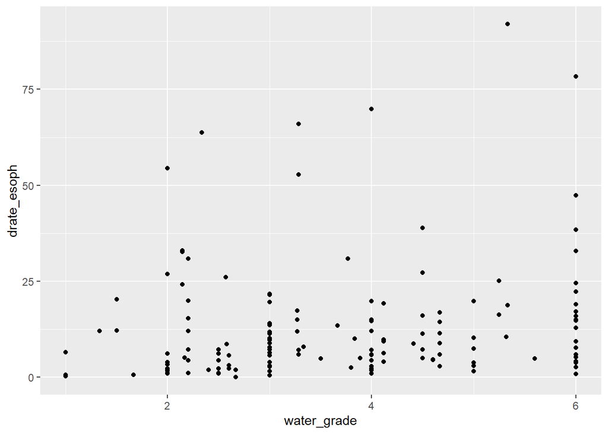

```r
my_plot <- my_plot + geom_point(aes(x = water_grade, y = drate_esoph))
my_plot
```

Now we have a basic plot! but we can do a few more things to make it look nice.

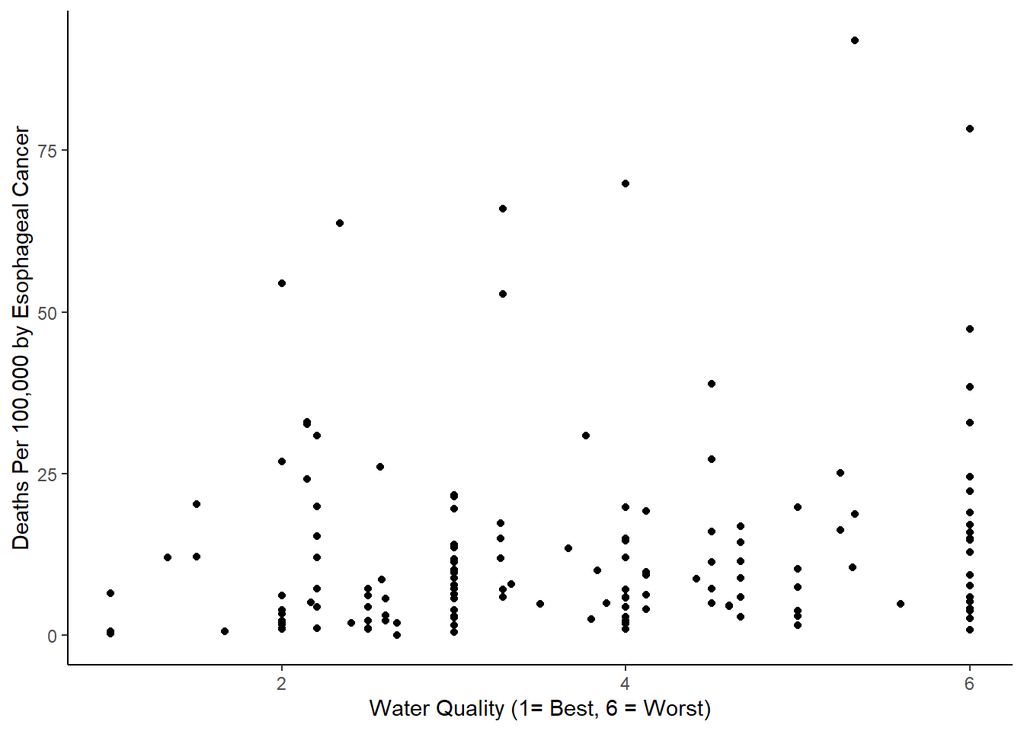

```r
# change the theme to another default ggpot theme
my_plot <- my_plot + theme_classic()

# chagne the labels
my_plot <- my_plot + xlab("Water Quality (1= Best, 6 = Worst)")
my_plot <- my_plot + ylab("Deaths Per 100,000 by Esophageal Cancer")

my_plot
```

At each step we are assigning `my_plot` everything in the existing `my_plot` plus a new lawyer. Like I said above, we could do this all in one step and get the same result. We just add each layer with the *+* operator. ( I wont print the graph again, but you can try for yourself and see it is the same.)

```r
  my_plot <- ggplot(ps2_df) +
    geom_point(aes(x = water_grade, y = drate_esoph)) +
    xlab("Water Quality (1= Best, 6 = Worst)") +
    ylab("Deaths Per 100,000 by Esophageal Cancer") +
    theme_classic()
```

This is really just scratching the surface but should give you some idea of what is possible. I will also say that it is more important to understand the fundamental syntax then to remember a bunch of specific commands or options. When I make plots, I end up googling almost everything I want to do. This does not take much time though because I understand how the package works and can implement any new option or function I find.

## Binned Scatter

One particular plot we will need for this class is a binned scatter plot. This is a scatter plot where each point represents the mean of all points within a given bandwidth. There is not a simple way to do this with ggplot2. There are some user written packages out there to do this, but I did not love any of the ones I found. More importantly, this is a great opportunity to see (and learn) how combining data manipulation with ggplot2 can open up many more plotting and data visualization possibilities.

Let’s go back to the problem set 3 data and use a binned scatter to look at the relationship between age and earnings. We can start by cutting the age data into groups (creating bins for the binned scatter). Let’s just use base R and the cut function

```r
ps3_df$age_cat <- cut(ps3_df$age, breaks = 20)
```

Now take the mean of x and y variables by group using tidyverse. ungrouping the data after a group is a good habit to get into so you don’t accidentally use grouped data later on.

```r
bin_df <- ps3_df %>%
  group_by(age_cat) %>%
  summarise(across(c("age", "earnings"), mean, na.rm = TRUE), n_obs = n()) %>%
  ungroup()
```

Now that we have our data we just need to plot it.

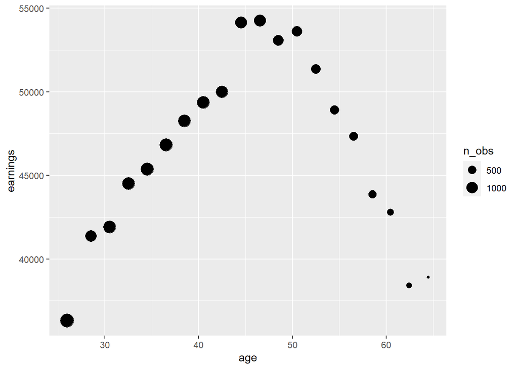

```r
# initialize ggplot
plot1 <- ggplot(data = bin_df, aes(x = age, y = earnings, weight=n_obs)) +
  geom_point(aes(size = n_obs))
plot1
```

## Lines of Best Fit

Sometimes we want to fit a line to our plot. It is possible to run a model and plot the results, but it is often easier to use some built in ggplot tools. *geom_smooth* is great for plotting linear regressions. Lets remake our binned scatter plot above, but this time with a line of best fit.

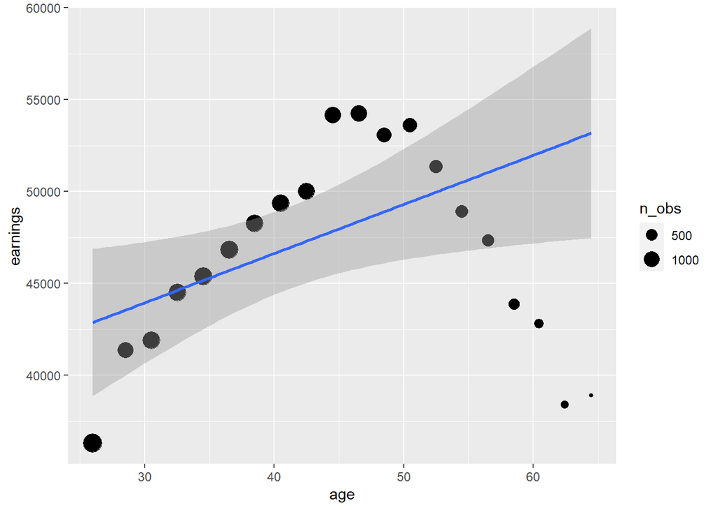

```r
# initialize ggplot
plot1 <- ggplot(data = bin_df, aes(x = age, y = earnings, weight=n_obs)) +
  geom_point(aes(size = n_obs)) +
  geom_smooth(method='lm', formula= y~x)
plot1
```

This particular plot looks more quadratic. we can adjust variables in our regression using the `I()` function just like with formulas in model functions.

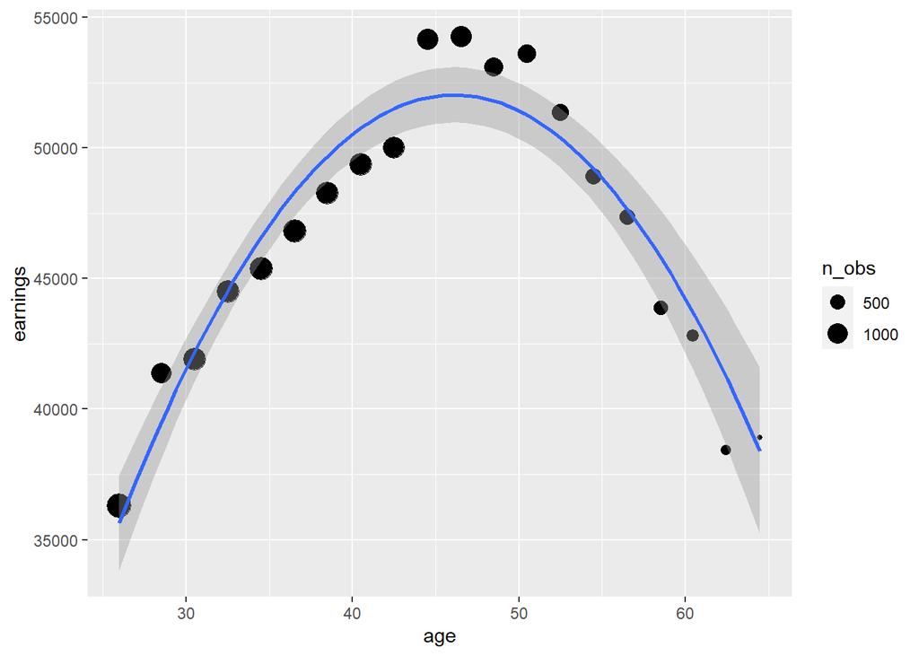

```r
# quadratic

plot2 <- ggplot(data = bin_df, aes(x = age, y = earnings, weight=n_obs)) +
  geom_point(aes(size = n_obs)) +
  geom_smooth(method='lm', formula= y~x + I(x^2))
plot2
```

# For Loop

For loops are used to repeat a piece of code multiple types. For example

```r
for(i in c(1,2,3)){
  print(i)
}
```

```
## [1] 1
## [1] 2
## [1] 3
```

The syntax starts with an object name. In this case I used *i*, but you can put any valid object name there. Next you write *in* and give the loop something to iterate over. Here I did the vector ” c(1,2,3)” of numbers 1-3. That means i takes the value of 1 and runs the code in the brackets, then i takes the value of 2 and runs the code and so on.

The colon operator can be useful here. it generating all integers between to numbers.

```r
1:5
```

```
## [1] 1 2 3 4 5
```

so we can shorten loops like so

```r
for(i in 1:5 ){
  print(i)
}
```

```
## [1] 1
## [1] 2
## [1] 3
## [1] 4
## [1] 5
```

## Pset 1 part 2

There is only one case in the problem sets where you will really need a for loop. The problem set talks you through the Stata code. The same level of instruction in R is below.

```r
# set seed so randomization is consistent
set.seed(1492)

# we want to loop through this 5 times
for(i in 1:5){

  # print iteration index "i" to track progress
  print(i)

  # add a column with random charter assignment
  ps1_df <- ps1_df %>%
    # permute charter school vector randomly
    mutate(rand_charter =  sample(charter))

  # print variable we are testing
  print("pp_curr_opp_exp")

  # run test and print
  test1 <- t.test(pp_curr_opp_exp ~ rand_charter, data = ps1_df)
  print(test1)

  # put additional tests here

}
```

```
## [1] 1
## [1] "pp_curr_opp_exp"
##
##  Welch Two Sample t-test
##
## data:  pp_curr_opp_exp by rand_charter
## t = 2.4026, df = 239.46, p-value = 0.01704
## alternative hypothesis: true difference in means between group 0 and group 1 is not equal to 0
## 95 percent confidence interval:
##   42.41022 428.58432
## sample estimates:
## mean in group 0 mean in group 1
##        6815.045        6579.548
##
## [1] 2
## [1] "pp_curr_opp_exp"
##
##  Welch Two Sample t-test
##
## data:  pp_curr_opp_exp by rand_charter
## t = -0.65851, df = 219.27, p-value = 0.5109
## alternative hypothesis: true difference in means between group 0 and group 1 is not equal to 0
## 95 percent confidence interval:
##  -299.098  149.283
## sample estimates:
## mean in group 0 mean in group 1
##        6788.296        6863.204
##
## [1] 3
## [1] "pp_curr_opp_exp"
##
##  Welch Two Sample t-test
##
## data:  pp_curr_opp_exp by rand_charter
## t = 1.1447, df = 211.27, p-value = 0.2536
## alternative hypothesis: true difference in means between group 0 and group 1 is not equal to 0
## 95 percent confidence interval:
##  -101.9365  384.2622
## sample estimates:
## mean in group 0 mean in group 1
```

[output cut: 14 more lines]

```
##        6776.679        6986.395
##
## [1] 5
## [1] "pp_curr_opp_exp"
##
##  Welch Two Sample t-test
##
## data:  pp_curr_opp_exp by rand_charter
## t = 0.22876, df = 207.67, p-value = 0.8193
## alternative hypothesis: true difference in means between group 0 and group 1 is not equal to 0
## 95 percent confidence interval:
##  -224.4221  283.3410
## sample estimates:
## mean in group 0 mean in group 1
##         6797.29         6767.83
```